# 1.1 Feature Extraction

ORB-SLAM3 — Visuelle Merkmale erkennen und beschreiben

Autor:in

Nediljko Andrijanic

Veröffentlichungsdatum

6. Mai 2026

## Agenda

1. Was sieht die Kamera?
2. **Schritt 1–2:** Graustufen & Gauss-Filter
3. **Schritt 3:** Bildpyramide — Skalierungsinvarianz
4. **Schritt 4–5:** FAST Detektor & Adaptiver Schwellenwert
5. **Schritt 6:** Quadtree — Gleichmäßige Verteilung
6. **Schritt 7:** Harris Score → **Ergebnis: beste Keypoints** :::

## 1.1 Feature Extraction — Pipeline

```
flowchart LR
    A["Kamerabild\nRGB"] --> B["1. Graustufen"]
    B --> C["2. Gauss-Filter"]
    C --> D["3. Bildpyramide\n8 Stufen"]
    D --> E["4. FAST Detektor\npro Stufe"]
    E --> F["5. Adaptiver\nSchwellenwert"]
    F --> G["6. Quadtree\nVerteilung"]
    G --> H["7. Harris Score\nRanking"]
    H --> Z["Keypoints\n(x, y)\npro Frame"]

    style A fill:#1d3557,color:#fff,font-size:14px
    style B fill:#457b9d,color:#fff,font-size:14px
    style C fill:#457b9d,color:#fff,font-size:14px
    style D fill:#e63946,color:#fff,font-size:14px
    style E fill:#e63946,color:#fff,font-size:14px
    style F fill:#e63946,color:#fff,font-size:14px
    style G fill:#e63946,color:#fff,font-size:14px
    style H fill:#e63946,color:#fff,font-size:14px
    style Z fill:#2d6a4f,color:#fff,font-size:14px
```

**Blau** = Vorverarbeitung | **Rot** = ORB-SLAM3 spezifisch | **Grün** = Ergebnis 1.1 → Deskriptor (Patch + Binäre Tests) kommt in **1.2 Visuelle Odometrie** :::

## Was sieht die Kamera?

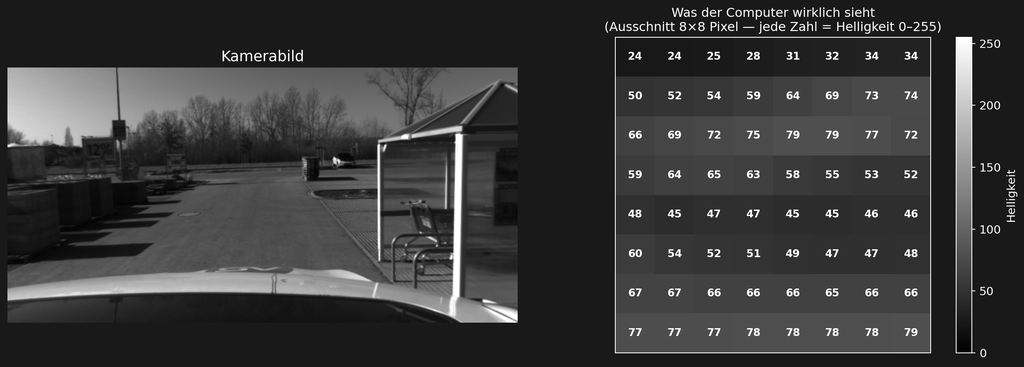

**Ein Bild = Matrix aus Zahlen. 0 = schwarz, 255 = weiß. Feature Extraction findet die wichtigsten Positionen in dieser Matrix.** :::

## Schritt 1: Graustufen

**Eingang:** RGB-Kamerabild → **Ausgang → Schritt 2:** Graustufenbild (1 Kanal, Helligkeit 0–255)

**Warum?** Farbe liefert keine geometrische Information. Nur Helligkeit zählt.

$$I_{grau} = 0.299 \cdot R + 0.587 \cdot G + 0.114 \cdot B$$

[figure not shown]

## Schritt 2: Gauss-Filter — Theorie

**Eingang:** Graustufenbild → **Ausgang → Schritt 3:** geglättetes Bild (Rauschen reduziert)

**Problem:** Kamerasensoren erzeugen Rauschen — zufällige Helligkeits-Schwankungen die keine echten Ecken sind.

**Lösung — Gauss-Filter:**

Jeder Pixel bekommt einen neuen Wert = **gewichteter Durchschnitt** seiner Nachbarn.

$$G(x,y) = \frac{1}{2\pi\sigma^2} e^{-\frac{x^2+y^2}{2\sigma^2}}$$

- Pixel in der **Mitte** zählt am meisten
- Pixel am **Rand** zählen weniger
- Rauschen wird geglättet
- Echte Kanten bleiben erhalten

[output not shown]

Alle Gewichte summieren sich zu **1.0**.

## Schritt 2: Gauss-Filter — Rauschen sichtbar machen

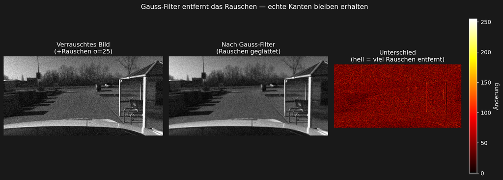

## Schritt 2: Gauss-Filter — Animation

**Schritt 1:** Das 5×5 Grid — alle Pixel ~20 (dunkel), aber Pixel (2,2) = **250** (heller Ausreißer)

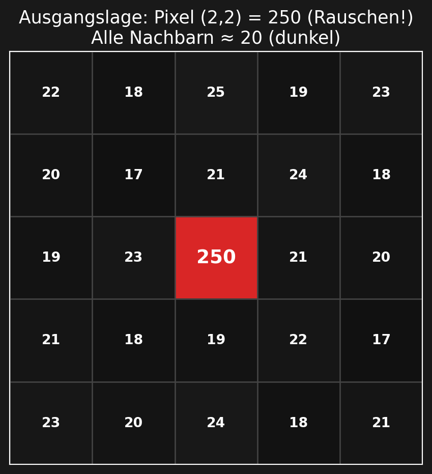

[figure not shown]

:::

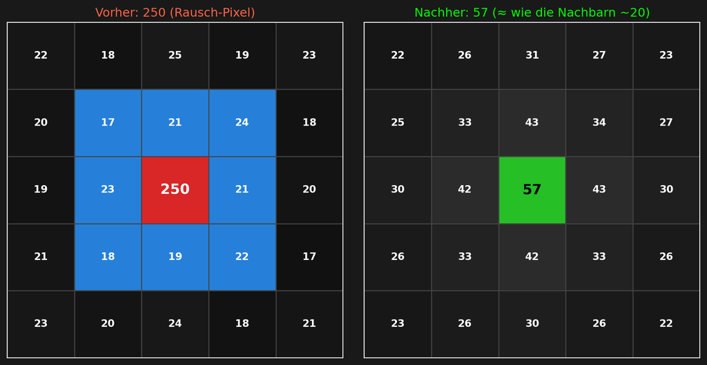

## Schritt 2: Gauss-Filter — Die Rechnung

[figure not shown]

:::

## Schritt 3: Bildpyramide — Theorie

**Eingang:** geglättetes Bild → **Ausgang → Schritt 4:** 8 skalierte Versionen desselben Bildes

**Problem:** Dasselbe Feature sieht je nach Entfernung anders groß aus.

**Beispiel:** - Eine Straßenlaterne **2m** entfernt → groß im Bild - Dieselbe Laterne **10m** entfernt → kleiner im Bild

→ ORB ohne Pyramide würde **dieselbe Laterne nicht wiedererkennen**.

**Lösung — Bildpyramide:**

Verarbeite das Bild in **8 Größenstufen** (Skalierungsfaktor 1.2):

| Stufe | Faktor | Bildgröße (Bsp.) |
| --- | --- | --- |
| 0 | 1.0× | 800×400 |
| 1 | 0.83× | 667×333 |
| 3 | 0.58× | 463×231 |
| 7 | 0.28× | 223×111 |

**Warum funktioniert das?**

Ein Feature das auf Stufe 0 zu groß erscheint, wird auf Stufe 2 oder 3 erkannt — dort sieht es “normal groß” aus.

```
Stufe 0: 800×400  ─── FAST ──→ Features
  ↓ ÷1.2
Stufe 1: 667×333  ─── FAST ──→ Features
  ↓ ÷1.2
Stufe 2: 556×278  ─── FAST ──→ Features
  ...
Stufe 7: 223×111  ─── FAST ──→ Features
```

Alle Features → auf Originalmaßstab zurückgerechnet.

**Wichtig — Rückrechnung auf echte Koordinaten:**

Ein Feature das auf Stufe $k$ bei Position $(x_k, y_k)$ gefunden wird, entspricht im **Originalbild** der Position:

$$x_\text{original} = x_k \times 1.2^k \qquad y_\text{original} = y_k \times 1.2^k$$

Beispiel: Feature auf Stufe 3 bei $(100, 50)$ → im Original bei $(100 \times 1.73,\ 50 \times 1.73) = (173,\ 87)$

Alle Features aus allen 8 Stufen werden so ins Original umgerechnet und dann gemeinsam weiterverarbeitet.

## Schritt 3: Bildpyramide — Beispiel

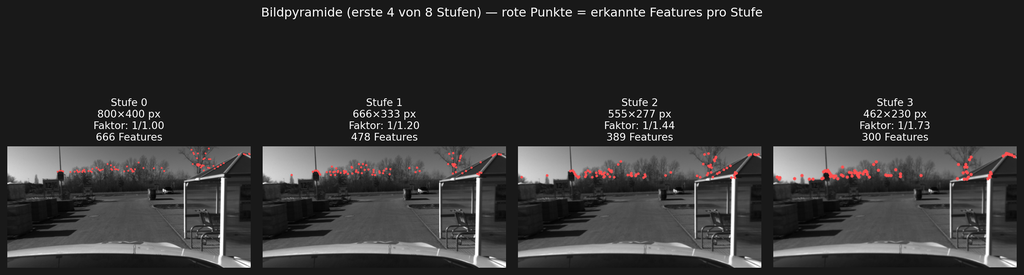

**Was zeigt dieses Bild?**

Jedes Panel zeigt dasselbe Kamerabild, aber jede Stufe ist **1.2× kleiner** als die vorherige. Die roten Punkte sind Features die FAST auf **dieser Stufe** findet.

- **Stufe 0** (Original): FAST sucht nach Ecken mit Radius 3 Pixel → erkennt kleine, feine Features
- **Stufe 1–3** (verkleinert): Dasselbe Bild kleiner → ein Objekt das im Original “zu groß” war (z.B. breite Kante) wird jetzt kompakt genug für den r=3 Kreis → FAST erkennt es erst jetzt
- Deshalb: **unterschiedliche Features** erscheinen auf unterschiedlichen Stufen!

**Ergebnis:** Features werden **skalierungsinvariant** — ORB-SLAM3 erkennt dasselbe Objekt in 2m und 10m Entfernung.

### Sub-Pixel Genauigkeit durch die Pyramide

Besonders wichtig: Die Pyramide ermöglicht auch **sehr kleine Features** (weit entfernte Objekte) mit hoher Präzision zu lokalisieren.

Wenn FAST ein Feature auf Stufe $k$ findet, wird seine Position auf das **Originalmaßstab zurückgerechnet**:

$$\text{Position}_\text{original} = \text{Position}_\text{Stufe k} \times 1.2^k$$

Das bedeutet: 1 Schritt in Stufe $k$ = $1.2^k$ Pixel im Original. Die **effektive Auflösung** ist also:

[output not shown]

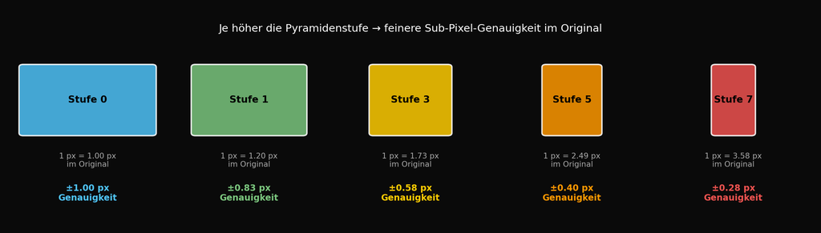

## Schritt 4: FAST Detektor — Theorie

**Eingang:** jede Pyramidenstufe (8 Bilder) → **Ausgang → Schritt 5:** viele Keypoints mit Position (x, y)

**Ziel:** Finde Ecken im Bild. Eine Ecke ist ein Punkt, wo sich Helligkeit abrupt in zwei Richtungen ändert.

**Algorithmus — für jeden Pixel p:**

1. Zeichne einen Kreis mit **16 Nachbarn** (Radius 3)
2. Prüfe ob ≥ **9 zusammenhängende** Pixel entweder:
   - **Heller** sind: $I_x > I_p + t$
   - **Dunkler** sind: $I_x < I_p - t$
3. Falls ja → **Ecke erkannt**

$t$ = Schwellenwert

**Warum 9?** Mindestens die Hälfte+1 des Kreises (16/2 + 1 = 9) muss konsistent sein.

```
     ×  ×  ×
   ×  1  2  3  ×
  × 16        4 ×
  × 15    p   5 ×    ← Zentrum p
  × 14        6 ×
   × 13  8  7  ×
     × 12 11 10 9 ×

Wenn z.B. Pixel 1–10 alle
dunkler als p−t sind:
→ 10 zusammenhängende
→ ECKE!
```

## Schritt 4: FAST Detektor — Pixel-Grid Beispiel

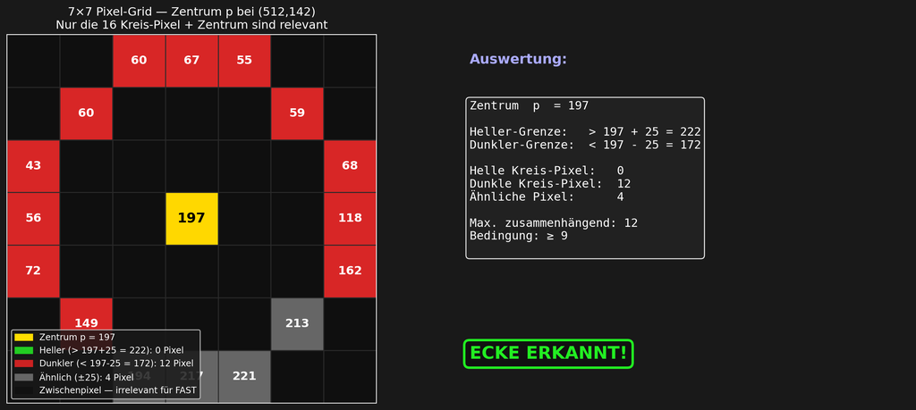

## Schritt 5: Adaptiver FAST-Schwellenwert

**Eingang:** Keypoints (evtl. manche Zonen leer) → **Ausgang → Schritt 6:** Keypoints aus allen Bildbereichen

**Theorie:** Nicht alle Bildregionen haben gleich viel Textur.

**Strategie:**

**Warum wichtig?**

Ohne Fallback: texturarme Zonen (Himmel, Wände) → **0 Features** → Tracking verloren!

Mit Fallback: auch schwache Ecken werden erkannt → **stabiles Tracking**.

**In ORB-SLAM3 Code:**

```python
kp = FAST(img, iniThFAST)

if len(kp) == 0:
    # Fallback!
    kp = FAST(img, minThFAST)
```

**Einfluss des Schwellenwerts t:**

| t | Empfindlichkeit | Features |
| --- | --- | --- |
| 60 | niedrig | wenige, starke |
| 10 | mittel | ausgewogen |
| 7 | hoch | viele, auch schwache |

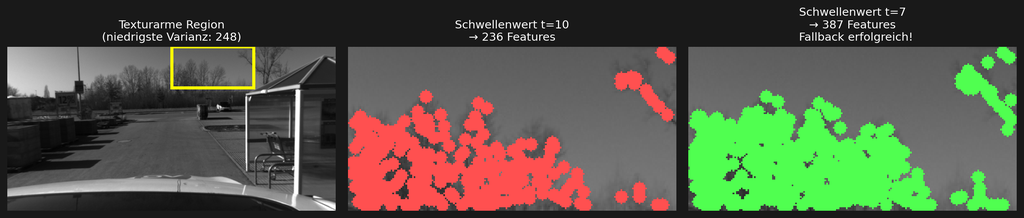

## Schritt 6: Quadtree-Verteilung

**Eingang:** viele Keypoints (geclustert an Kanten) → **Ausgang → Schritt 7:** gleichmäßig verteilte Keypoints

**Theorie:** FAST liefert sehr viele Features — aber sie clustern sich alle an denselben Kanten.

**Problem ohne Quadtree:**

- 90% der Features an einer Kante
- Andere Bildbereiche = **leer**
- Wenn Kamera dreht → **alle Features verschwinden**!

**Lösung — Quadtree:**

**Ergebnis:** Features gleichmäßig über das Bild verteilt.

**Visualisierung:**

```
Bild [800×400]
┌──────────┬──────────┐
│  Q1      │  Q2      │  pro Quadrant:
│  125 kps │  125 kps │  max. 125 Features
├──────────┼──────────┤  → falls mehr:
│  Q3      │  Q4      │     nochmals teilen
│  125 kps │  125 kps │
└──────────┴──────────┘

→ 500 Features total,
  gleichmäßig verteilt
```

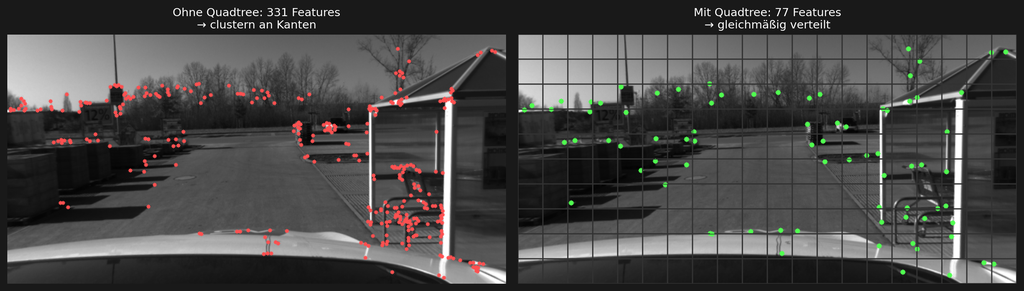

## Schritt 7: Harris Corner Score

**Eingang:** verteilte Keypoints (mehrere pro Zelle) → **Ausgang (1.1 fertig):** Top-N stabilste Keypoints mit Position (x,y)

**Theorie:** Quadtree liefert pro Zelle mehrere Kandidaten — welcher ist der Beste?

**Harris-Response:**

$$R = \det(M) - k \cdot \text{trace}(M)^2, \quad k \approx 0.04$$

$$M = \begin{pmatrix} \sum I_x^2 & \sum I_x I_y \\ \sum I_x I_y & \sum I_y^2 \end{pmatrix}$$

**Interpretation:** - $R \gg 0$ → **starke Ecke** (beide Richtungen haben Kante) - $R < 0$ → Kante (nur eine Richtung) - $R \approx 0$ → flache Region (keine Kante)

Pro Quadtree-Zelle → behalte den Keypoint mit dem **höchsten R**.

**Warum nicht einfach den FAST-Score nehmen?**

FAST misst nur ob ein Pixel eine Ecke ist (ja/nein). Harris misst **wie stark** die Ecke ist.

→ Harris findet **geometrisch stabilere** Ecken die über viele Frames hinweg wiedererkannt werden.

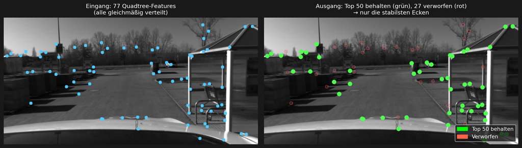

## Zusammenfassung 1.1

| Schritt | Algorithmus | Was passiert | Ergebnis |
| --- | --- | --- | --- |
| 1 | Graustufen | RGB → 1 Kanal | Graustufenbild |
| 2 | Gauss-Filter | Rauschen glätten | Sauberes Bild |
| 3 | Bildpyramide | 8 Größenstufen | Skalenraum |
| 4 | FAST | Ecken finden | Keypoint-Positionen |
| 5 | Adaptiver FAST | Fallback bei wenig Textur | Keine leeren Zonen |
| 6 | Quadtree | Gleichmäßig verteilen | Uniformes Feature-Grid |
| 7 | Harris Score | Qualität bewerten | **Beste Keypoints (x,y)** |

**Ergebnis 1.1:** Pro Frame N Keypoints mit Position (x,y) — bereit für 1.2 Visuelle Odometrie. :::